# Creating a raster stack of predictor layers

# Preparations

## Install packages

```r
if(!require("pacman")) install.packages("pacman"); library(pacman)
p_load(here,
       terra
       )
```

## Create directories

```r
dir.create(here("1_predictors", "data", "input"), recursive = TRUE)
dir.create(here("1_predictors", "data", "output"), recursive = TRUE)
```

# Data processing

## Create template rasters

Create two template raster files with resolutions of 0.05 deg. x 0.05 deg. (template_raster_low) and 0.025 deg. x 0.025 deg. (template_raster_high).

nrows = (ymax - ymin)/resolution ncols = (xmax - xmin)/resolution

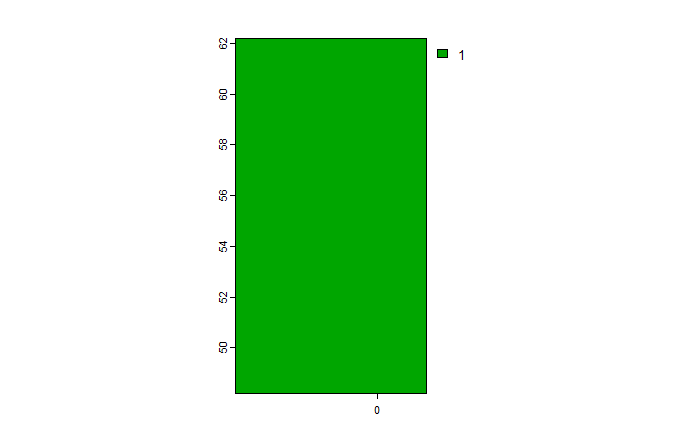

## Load predictor layers

*Ultimately, the predictor layers should be stored at Zenodo, downloaded and unzipped before loading them into the project.* *It might also be neater to load the predictor files in a loop.* *The individual layers would also require more meaningful names.*

bathymetry Emodnet_bathymetry_2024_0.01deg mud bias_adjusted_mud sand bias_adjusted_sand gravel bias_adjusted_gravel curr_vel_max max_velocity_original_coarse curr_vel_mean mean_velocity_original_coarse temp bottom_temp_original sal bias_corrected_downscaled_salinity chl bias_corrected_downscaled_chl spm_summer summer_SPM_original spm_winter winter_bias_corrected_downscaled_spm

```r
temp
```

```
class       : SpatRaster
dimensions  : 282, 805, 1  (nrow, ncol, nlyr)
resolution  : 0.02925, 0.051875  (x, y)
extent      : -14.73497, 8.811283, 47.36184, 61.99059  (xmin, xmax, ymin, ymax)
coord. ref. : lon/lat WGS 84 (EPSG:4326)
source      : bottom_temp_original.tif
name        :       temp
min value   : -0.4717362
max value   : 13.6231337
```

## Create additive log-ratios of sediment composition data

Mud, sand, and gravel content are compositional data that must sum to 100% (or 1 as fractional data). Projecting these data individually will lead to results that do not adhere to this. A workaround is to calculate additive log-ratios, project these and the calculate mud, sand, and gravel content from the projected additive log-ratios.

```r
alr_m <- log(mud/gravel)
alr_s <- log(sand/gravel)
```

## Project predictor layers

*Maybe this could also be looped.*

method  
character. Method used for estimating the new cell values of a SpatRaster. One of:

near: nearest neighbor. This method is fast, and it can be the preferred method if the cell values represent classes. It is not a good choice for continuous values. This is used by default if the first layer of x is categorical. bilinear: bilinear interpolation. This is the default if the first layer of x is numeric (not categorical). cubic: cubic interpolation. cubicspline: cubic spline interpolation. lanczos: Lanczos windowed sinc resampling. sum: the weighted sum of all non-NA contributing grid cells.

```r
temp_pr <- project(x = temp, y = template_raster_low)
chl_pr <- project(x = chl, y = template_raster_low)
```

## Back-transform additive log-ratios

mud = exp(alr_m)/(exp(alr_m) + exp(alr_s) + 1) sand = exp(alr_s)/(exp(alr_m) + exp(alr_s) + 1) gravel = 1 - (mud + sand)

## Create a raster stack

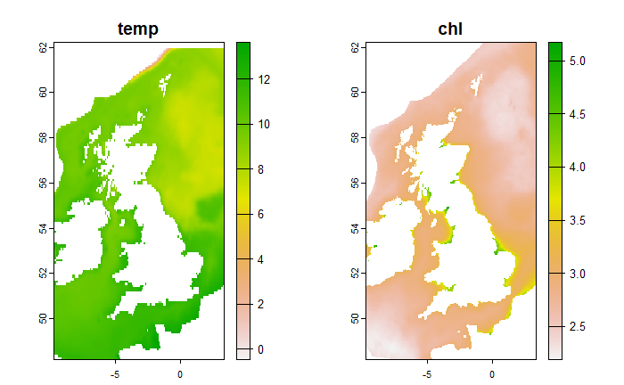

```r
env_vars <- c(temp_pr, chl_pr)
plot(env_vars)
```

## Load area of interest

```r
aoi <- vect(here("1_predictors", "data", "input", "UK_shelf.shp"))
```

## Crop raster stack to UK shelf extent

touches = TRUE?

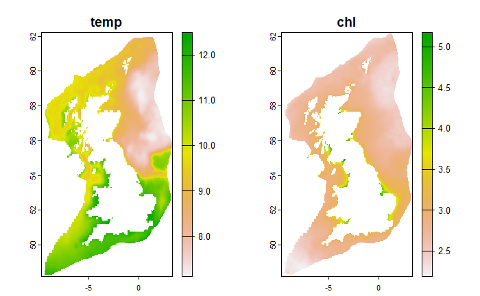

```r
env_vars <- crop(x = env_vars, y = aoi, mask = TRUE)
plot(env_vars)
```

## Blank out areas mapped as bedrock

The predictive seabed sediments map from the BGS includes bedrock at the seabed surface. Such areas should be blanked out in the raster stack.

```r
#sbs <- vect(here("1_predictors", "data", "input", "Predictive_SBS_UK_V1_ESRI", "Classified_Seabed_Sediments_Folk_UK_v1.shp"))
#rock <- subset(sbs, sbs$Folk_Class == "Rock")
```

# Save raster stack

```r
writeRaster(x = env_vars, filename = here("1_predictors", "data", "output", "env_vars.tif"), overwrite = TRUE)
```